# Risk Factor Analysis

## Outcome Variable

**Outcome Variable:** sstunted

## Predictor Variables

**Intervention Variable:** nrooms

**Adjustment Set:**

unadjusted

## Stratifying Variables

The analysis was stratified on these variable(s):

- agecat
- studyid
- country

## Data Summary

| agecat | studyid | country | nrooms | sstunted | n_cell | n |
| --- | --- | --- | --- | --- | --- | --- |
| Birth | ki0047075b-MAL-ED | BANGLADESH | 1 | 0 | 139 | 234 |
| Birth | ki0047075b-MAL-ED | BANGLADESH | 1 | 1 | 5 | 234 |
| Birth | ki0047075b-MAL-ED | BANGLADESH | 2 | 0 | 49 | 234 |
| Birth | ki0047075b-MAL-ED | BANGLADESH | 2 | 1 | 1 | 234 |
| Birth | ki0047075b-MAL-ED | BANGLADESH | 3 | 0 | 28 | 234 |
| Birth | ki0047075b-MAL-ED | BANGLADESH | 3 | 1 | 0 | 234 |
| Birth | ki0047075b-MAL-ED | BANGLADESH | 4+ | 0 | 12 | 234 |
| Birth | ki0047075b-MAL-ED | BANGLADESH | 4+ | 1 | 0 | 234 |
| Birth | ki0047075b-MAL-ED | BRAZIL | 1 | 0 | 3 | 174 |
| Birth | ki0047075b-MAL-ED | BRAZIL | 1 | 1 | 0 | 174 |
| Birth | ki0047075b-MAL-ED | BRAZIL | 2 | 0 | 19 | 174 |
| Birth | ki0047075b-MAL-ED | BRAZIL | 2 | 1 | 0 | 174 |
| Birth | ki0047075b-MAL-ED | BRAZIL | 3 | 0 | 46 | 174 |
| Birth | ki0047075b-MAL-ED | BRAZIL | 3 | 1 | 4 | 174 |
| Birth | ki0047075b-MAL-ED | BRAZIL | 4+ | 0 | 99 | 174 |
| Birth | ki0047075b-MAL-ED | BRAZIL | 4+ | 1 | 3 | 174 |
| Birth | ki0047075b-MAL-ED | INDIA | 1 | 0 | 67 | 191 |
| Birth | ki0047075b-MAL-ED | INDIA | 1 | 1 | 2 | 191 |
| Birth | ki0047075b-MAL-ED | INDIA | 2 | 0 | 64 | 191 |
| Birth | ki0047075b-MAL-ED | INDIA | 2 | 1 | 4 | 191 |
| Birth | ki0047075b-MAL-ED | INDIA | 3 | 0 | 31 | 191 |
| Birth | ki0047075b-MAL-ED | INDIA | 3 | 1 | 1 | 191 |
| Birth | ki0047075b-MAL-ED | INDIA | 4+ | 0 | 22 | 191 |
| Birth | ki0047075b-MAL-ED | INDIA | 4+ | 1 | 0 | 191 |
| Birth | ki0047075b-MAL-ED | NEPAL | 1 | 0 | 33 | 171 |
| Birth | ki0047075b-MAL-ED | NEPAL | 1 | 1 | 3 | 171 |
| Birth | ki0047075b-MAL-ED | NEPAL | 2 | 0 | 21 | 171 |
| Birth | ki0047075b-MAL-ED | NEPAL | 2 | 1 | 0 | 171 |
| Birth | ki0047075b-MAL-ED | NEPAL | 3 | 0 | 17 | 171 |
| Birth | ki0047075b-MAL-ED | NEPAL | 3 | 1 | 0 | 171 |

[output cut: 338 more lines]

The following strata were considered:

- agecat: 24 months, studyid: ki0047075b-MAL-ED, country: BANGLADESH
- agecat: 24 months, studyid: ki0047075b-MAL-ED, country: BRAZIL
- agecat: 24 months, studyid: ki0047075b-MAL-ED, country: INDIA
- agecat: 24 months, studyid: ki0047075b-MAL-ED, country: NEPAL
- agecat: 24 months, studyid: ki0047075b-MAL-ED, country: PERU
- agecat: 24 months, studyid: ki0047075b-MAL-ED, country: SOUTH AFRICA
- agecat: 24 months, studyid: ki0047075b-MAL-ED, country: TANZANIA, UNITED REPUBLIC OF
- agecat: 24 months, studyid: ki1000108-CMC-V-BCS-2002, country: INDIA
- agecat: 24 months, studyid: ki1000108-IRC, country: INDIA
- agecat: 24 months, studyid: ki1017093b-PROVIDE, country: BANGLADESH
- agecat: 24 months, studyid: ki1017093c-NIH-Crypto, country: BANGLADESH
- agecat: 24 months, studyid: ki1113344-GMS-Nepal, country: NEPAL
- agecat: 24 months, studyid: ki1114097-CONTENT, country: PERU
- agecat: 24 months, studyid: ki1135781-COHORTS, country: INDIA
- agecat: 24 months, studyid: kiGH5241-JiVitA-3, country: BANGLADESH
- agecat: 24 months, studyid: kiGH5241-JiVitA-4, country: BANGLADESH
- agecat: 6 months, studyid: ki0047075b-MAL-ED, country: BANGLADESH
- agecat: 6 months, studyid: ki0047075b-MAL-ED, country: BRAZIL
- agecat: 6 months, studyid: ki0047075b-MAL-ED, country: INDIA
- agecat: 6 months, studyid: ki0047075b-MAL-ED, country: NEPAL
- agecat: 6 months, studyid: ki0047075b-MAL-ED, country: PERU
- agecat: 6 months, studyid: ki0047075b-MAL-ED, country: SOUTH AFRICA
- agecat: 6 months, studyid: ki0047075b-MAL-ED, country: TANZANIA, UNITED REPUBLIC OF
- agecat: 6 months, studyid: ki1000108-CMC-V-BCS-2002, country: INDIA
- agecat: 6 months, studyid: ki1000108-IRC, country: INDIA
- agecat: 6 months, studyid: ki1017093b-PROVIDE, country: BANGLADESH
- agecat: 6 months, studyid: ki1017093c-NIH-Crypto, country: BANGLADESH
- agecat: 6 months, studyid: ki1113344-GMS-Nepal, country: NEPAL
- agecat: 6 months, studyid: ki1114097-CONTENT, country: PERU
- agecat: 6 months, studyid: ki1135781-COHORTS, country: INDIA
- agecat: 6 months, studyid: kiGH5241-JiVitA-3, country: BANGLADESH
- agecat: 6 months, studyid: kiGH5241-JiVitA-4, country: BANGLADESH
- agecat: Birth, studyid: ki0047075b-MAL-ED, country: BANGLADESH
- agecat: Birth, studyid: ki0047075b-MAL-ED, country: BRAZIL
- agecat: Birth, studyid: ki0047075b-MAL-ED, country: INDIA
- agecat: Birth, studyid: ki0047075b-MAL-ED, country: NEPAL
- agecat: Birth, studyid: ki0047075b-MAL-ED, country: PERU
- agecat: Birth, studyid: ki0047075b-MAL-ED, country: SOUTH AFRICA
- agecat: Birth, studyid: ki0047075b-MAL-ED, country: TANZANIA, UNITED REPUBLIC OF
- agecat: Birth, studyid: ki1000108-CMC-V-BCS-2002, country: INDIA
- agecat: Birth, studyid: ki1000108-IRC, country: INDIA
- agecat: Birth, studyid: ki1017093c-NIH-Crypto, country: BANGLADESH
- agecat: Birth, studyid: ki1114097-CONTENT, country: PERU
- agecat: Birth, studyid: ki1135781-COHORTS, country: INDIA
- agecat: Birth, studyid: kiGH5241-JiVitA-3, country: BANGLADESH
- agecat: Birth, studyid: kiGH5241-JiVitA-4, country: BANGLADESH

### Dropped Strata

Some strata were dropped due to rare outcomes:

- agecat: Birth, studyid: ki0047075b-MAL-ED, country: BANGLADESH
- agecat: Birth, studyid: ki0047075b-MAL-ED, country: BRAZIL
- agecat: Birth, studyid: ki0047075b-MAL-ED, country: INDIA
- agecat: Birth, studyid: ki0047075b-MAL-ED, country: NEPAL
- agecat: Birth, studyid: ki0047075b-MAL-ED, country: PERU
- agecat: Birth, studyid: ki0047075b-MAL-ED, country: SOUTH AFRICA
- agecat: Birth, studyid: ki0047075b-MAL-ED, country: TANZANIA, UNITED REPUBLIC OF
- agecat: Birth, studyid: ki1000108-CMC-V-BCS-2002, country: INDIA
- agecat: Birth, studyid: ki1000108-IRC, country: INDIA
- agecat: Birth, studyid: ki1017093c-NIH-Crypto, country: BANGLADESH
- agecat: Birth, studyid: ki1114097-CONTENT, country: PERU
- agecat: Birth, studyid: ki1135781-COHORTS, country: INDIA
- agecat: 6 months, studyid: ki0047075b-MAL-ED, country: BANGLADESH
- agecat: 6 months, studyid: ki0047075b-MAL-ED, country: BRAZIL
- agecat: 6 months, studyid: ki0047075b-MAL-ED, country: INDIA
- agecat: 6 months, studyid: ki0047075b-MAL-ED, country: NEPAL
- agecat: 6 months, studyid: ki0047075b-MAL-ED, country: PERU
- agecat: 6 months, studyid: ki0047075b-MAL-ED, country: SOUTH AFRICA
- agecat: 6 months, studyid: ki0047075b-MAL-ED, country: TANZANIA, UNITED REPUBLIC OF
- agecat: 6 months, studyid: ki1000108-CMC-V-BCS-2002, country: INDIA
- agecat: 6 months, studyid: ki1000108-IRC, country: INDIA
- agecat: 6 months, studyid: ki1017093b-PROVIDE, country: BANGLADESH
- agecat: 6 months, studyid: ki1017093c-NIH-Crypto, country: BANGLADESH
- agecat: 6 months, studyid: ki1113344-GMS-Nepal, country: NEPAL
- agecat: 6 months, studyid: ki1114097-CONTENT, country: PERU
- agecat: 6 months, studyid: ki1135781-COHORTS, country: INDIA
- agecat: 24 months, studyid: ki0047075b-MAL-ED, country: BANGLADESH
- agecat: 24 months, studyid: ki0047075b-MAL-ED, country: BRAZIL
- agecat: 24 months, studyid: ki0047075b-MAL-ED, country: INDIA
- agecat: 24 months, studyid: ki0047075b-MAL-ED, country: NEPAL
- agecat: 24 months, studyid: ki0047075b-MAL-ED, country: PERU
- agecat: 24 months, studyid: ki0047075b-MAL-ED, country: SOUTH AFRICA
- agecat: 24 months, studyid: ki0047075b-MAL-ED, country: TANZANIA, UNITED REPUBLIC OF
- agecat: 24 months, studyid: ki1000108-CMC-V-BCS-2002, country: INDIA
- agecat: 24 months, studyid: ki1000108-IRC, country: INDIA
- agecat: 24 months, studyid: ki1017093b-PROVIDE, country: BANGLADESH
- agecat: 24 months, studyid: ki1017093c-NIH-Crypto, country: BANGLADESH
- agecat: 24 months, studyid: ki1114097-CONTENT, country: PERU
- agecat: 24 months, studyid: ki1135781-COHORTS, country: INDIA

## Methods Detail

We’re interested in the causal parameters $E[Y_a]$ for all values of $a \in \mathcal{A}$. These parameters represent the mean outcome if, possibly contrary to fact, we intervened to set all units to have $A=a$. Under the randomization and positivity assumptions, these are identified by the statistical parameters $\psi_a=E_W[E_{Y|A,W}(Y|A=a,W)]$. In addition, we’re interested in the mean of $Y$, $E[Y]$ under no intervention (the observed mean). We will estimate these parameters by using SuperLearner to fit the relevant likelihood factors – $E_{Y|A,W}(Y|A=a,W)$ and $p(A=a|W)$, and then updating our likelihood fit using a joint TMLE.

For unadjusted analyses ($W=\{\}$), initial likelihoods were estimated using Lrnr_glm to estimate the simple $E(Y|A)$ and Lrnr_mean to estimate $p(A)$. For adjusted analyses, a small library containing Lrnr_glmnet, Lrnr_xgboost, and Lrnr_mean was used.

Having estimated these parameters, we will then use the delta method to estimate relative risks and attributable risks relative to a prespecified baseline level of $A$.

# Results Detail

## Results Plots

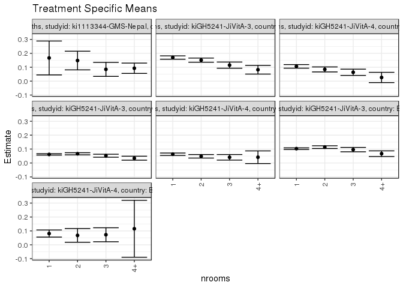

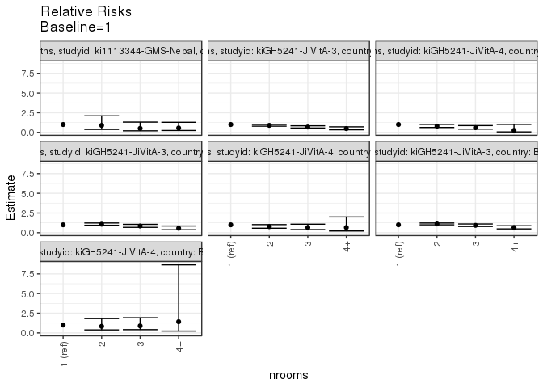

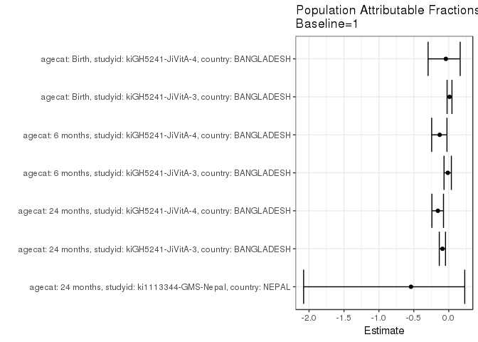

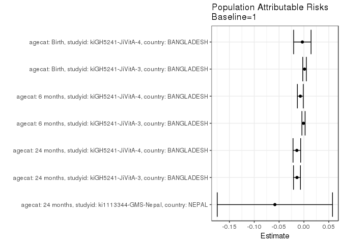

## Results Table

### Parameter: TSM

| agecat | studyid | country | intervention_level | baseline_level | estimate | ci_lower | ci_upper |
| --- | --- | --- | --- | --- | --- | --- | --- |
| Birth | kiGH5241-JiVitA-3 | BANGLADESH | 1 | NA | 0.1029448 | 0.0971134 | 0.1087761 |
| Birth | kiGH5241-JiVitA-3 | BANGLADESH | 2 | NA | 0.1139339 | 0.1041914 | 0.1236765 |
| Birth | kiGH5241-JiVitA-3 | BANGLADESH | 3 | NA | 0.0960922 | 0.0803894 | 0.1117951 |
| Birth | kiGH5241-JiVitA-3 | BANGLADESH | 4+ | NA | 0.0667808 | 0.0463867 | 0.0871749 |
| Birth | kiGH5241-JiVitA-4 | BANGLADESH | 1 | NA | 0.0810277 | 0.0553885 | 0.1066669 |
| Birth | kiGH5241-JiVitA-4 | BANGLADESH | 2 | NA | 0.0676329 | 0.0184477 | 0.1168180 |
| Birth | kiGH5241-JiVitA-4 | BANGLADESH | 3 | NA | 0.0722892 | 0.0219335 | 0.1226448 |
| Birth | kiGH5241-JiVitA-4 | BANGLADESH | 4+ | NA | 0.1153846 | -0.0893117 | 0.3200809 |
| 6 months | kiGH5241-JiVitA-3 | BANGLADESH | 1 | NA | 0.0614601 | 0.0565823 | 0.0663378 |
| 6 months | kiGH5241-JiVitA-3 | BANGLADESH | 2 | NA | 0.0661314 | 0.0585332 | 0.0737296 |
| 6 months | kiGH5241-JiVitA-3 | BANGLADESH | 3 | NA | 0.0521636 | 0.0414108 | 0.0629164 |
| 6 months | kiGH5241-JiVitA-3 | BANGLADESH | 4+ | NA | 0.0343898 | 0.0202702 | 0.0485094 |
| 6 months | kiGH5241-JiVitA-4 | BANGLADESH | 1 | NA | 0.0629258 | 0.0542711 | 0.0715805 |
| 6 months | kiGH5241-JiVitA-4 | BANGLADESH | 2 | NA | 0.0479766 | 0.0353773 | 0.0605760 |
| 6 months | kiGH5241-JiVitA-4 | BANGLADESH | 3 | NA | 0.0407524 | 0.0207829 | 0.0607218 |
| 6 months | kiGH5241-JiVitA-4 | BANGLADESH | 4+ | NA | 0.0412574 | -0.0043273 | 0.0868421 |
| 24 months | ki1113344-GMS-Nepal | NEPAL | 1 | NA | 0.1666667 | 0.0448053 | 0.2885281 |
| 24 months | ki1113344-GMS-Nepal | NEPAL | 2 | NA | 0.1481481 | 0.0810822 | 0.2152141 |
| 24 months | ki1113344-GMS-Nepal | NEPAL | 3 | NA | 0.0847458 | 0.0344452 | 0.1350463 |
| 24 months | ki1113344-GMS-Nepal | NEPAL | 4+ | NA | 0.0928270 | 0.0558449 | 0.1298091 |
| 24 months | kiGH5241-JiVitA-3 | BANGLADESH | 1 | NA | 0.1697907 | 0.1578263 | 0.1817552 |
| 24 months | kiGH5241-JiVitA-3 | BANGLADESH | 2 | NA | 0.1511482 | 0.1362252 | 0.1660713 |
| 24 months | kiGH5241-JiVitA-3 | BANGLADESH | 3 | NA | 0.1152160 | 0.0930582 | 0.1373739 |
| 24 months | kiGH5241-JiVitA-3 | BANGLADESH | 4+ | NA | 0.0819673 | 0.0507569 | 0.1131776 |
| 24 months | kiGH5241-JiVitA-4 | BANGLADESH | 1 | NA | 0.1062775 | 0.0934115 | 0.1191436 |
| 24 months | kiGH5241-JiVitA-4 | BANGLADESH | 2 | NA | 0.0843170 | 0.0663258 | 0.1023083 |
| 24 months | kiGH5241-JiVitA-4 | BANGLADESH | 3 | NA | 0.0636743 | 0.0412240 | 0.0861246 |
| 24 months | kiGH5241-JiVitA-4 | BANGLADESH | 4+ | NA | 0.0264228 | -0.0104491 | 0.0632946 |

### Parameter: E(Y)

| agecat | studyid | country | intervention_level | baseline_level | estimate | ci_lower | ci_upper |
| --- | --- | --- | --- | --- | --- | --- | --- |
| Birth | kiGH5241-JiVitA-3 | BANGLADESH | NA | NA | 0.1041911 | 0.0995153 | 0.1088669 |
| Birth | kiGH5241-JiVitA-4 | BANGLADESH | NA | NA | 0.0778589 | 0.0559066 | 0.0998111 |
| 6 months | kiGH5241-JiVitA-3 | BANGLADESH | NA | NA | 0.0606467 | 0.0567904 | 0.0645030 |
| 6 months | kiGH5241-JiVitA-4 | BANGLADESH | NA | NA | 0.0557144 | 0.0488132 | 0.0626157 |
| 24 months | ki1113344-GMS-Nepal | NEPAL | NA | NA | 0.1082164 | 0.0809323 | 0.1355005 |
| 24 months | kiGH5241-JiVitA-3 | BANGLADESH | NA | NA | 0.1557958 | 0.1470502 | 0.1645415 |
| 24 months | kiGH5241-JiVitA-4 | BANGLADESH | NA | NA | 0.0920173 | 0.0825478 | 0.1014867 |

### Parameter: RR

| agecat | studyid | country | intervention_level | baseline_level | estimate | ci_lower | ci_upper |
| --- | --- | --- | --- | --- | --- | --- | --- |
| Birth | kiGH5241-JiVitA-3 | BANGLADESH | 1 | 1 | 1.0000000 | 1.0000000 | 1.0000000 |
| Birth | kiGH5241-JiVitA-3 | BANGLADESH | 2 | 1 | 1.1067484 | 0.9975981 | 1.2278412 |
| Birth | kiGH5241-JiVitA-3 | BANGLADESH | 3 | 1 | 0.9334351 | 0.7847918 | 1.1102321 |
| Birth | kiGH5241-JiVitA-3 | BANGLADESH | 4+ | 1 | 0.6487054 | 0.4780716 | 0.8802421 |
| Birth | kiGH5241-JiVitA-4 | BANGLADESH | 1 | 1 | 1.0000000 | 1.0000000 | 1.0000000 |
| Birth | kiGH5241-JiVitA-4 | BANGLADESH | 2 | 1 | 0.8346883 | 0.3828589 | 1.8197428 |
| Birth | kiGH5241-JiVitA-4 | BANGLADESH | 3 | 1 | 0.8921540 | 0.4124922 | 1.9295849 |
| Birth | kiGH5241-JiVitA-4 | BANGLADESH | 4+ | 1 | 1.4240150 | 0.2343038 | 8.6546566 |
| 6 months | kiGH5241-JiVitA-3 | BANGLADESH | 1 | 1 | 1.0000000 | 1.0000000 | 1.0000000 |
| 6 months | kiGH5241-JiVitA-3 | BANGLADESH | 2 | 1 | 1.0760063 | 0.9396617 | 1.2321345 |
| 6 months | kiGH5241-JiVitA-3 | BANGLADESH | 3 | 1 | 0.8487398 | 0.6790644 | 1.0608113 |
| 6 months | kiGH5241-JiVitA-3 | BANGLADESH | 4+ | 1 | 0.5595468 | 0.3695180 | 0.8473001 |
| 6 months | kiGH5241-JiVitA-4 | BANGLADESH | 1 | 1 | 1.0000000 | 1.0000000 | 1.0000000 |
| 6 months | kiGH5241-JiVitA-4 | BANGLADESH | 2 | 1 | 0.7624322 | 0.5672192 | 1.0248292 |
| 6 months | kiGH5241-JiVitA-4 | BANGLADESH | 3 | 1 | 0.6476258 | 0.3877248 | 1.0817443 |
| 6 months | kiGH5241-JiVitA-4 | BANGLADESH | 4+ | 1 | 0.6556513 | 0.2151583 | 1.9979649 |
| 24 months | ki1113344-GMS-Nepal | NEPAL | 1 | 1 | 1.0000000 | 1.0000000 | 1.0000000 |
| 24 months | ki1113344-GMS-Nepal | NEPAL | 2 | 1 | 0.8888889 | 0.3761572 | 2.1005141 |
| 24 months | ki1113344-GMS-Nepal | NEPAL | 3 | 1 | 0.5084746 | 0.1982758 | 1.3039733 |
| 24 months | ki1113344-GMS-Nepal | NEPAL | 4+ | 1 | 0.5569620 | 0.2422169 | 1.2806980 |
| 24 months | kiGH5241-JiVitA-3 | BANGLADESH | 1 | 1 | 1.0000000 | 1.0000000 | 1.0000000 |
| 24 months | kiGH5241-JiVitA-3 | BANGLADESH | 2 | 1 | 0.8902030 | 0.7889373 | 1.0044669 |
| 24 months | kiGH5241-JiVitA-3 | BANGLADESH | 3 | 1 | 0.6785767 | 0.5517501 | 0.8345558 |
| 24 months | kiGH5241-JiVitA-3 | BANGLADESH | 4+ | 1 | 0.4827546 | 0.3290711 | 0.7082116 |
| 24 months | kiGH5241-JiVitA-4 | BANGLADESH | 1 | 1 | 1.0000000 | 1.0000000 | 1.0000000 |
| 24 months | kiGH5241-JiVitA-4 | BANGLADESH | 2 | 1 | 0.7933665 | 0.6205629 | 1.0142894 |
| 24 months | kiGH5241-JiVitA-4 | BANGLADESH | 3 | 1 | 0.5991325 | 0.4152742 | 0.8643920 |
| 24 months | kiGH5241-JiVitA-4 | BANGLADESH | 4+ | 1 | 0.2486204 | 0.0610253 | 1.0128937 |

### Parameter: PAR

| agecat | studyid | country | intervention_level | baseline_level | estimate | ci_lower | ci_upper |
| --- | --- | --- | --- | --- | --- | --- | --- |
| Birth | kiGH5241-JiVitA-3 | BANGLADESH | 1 | NA | 0.0012464 | -0.0023945 | 0.0048872 |
| Birth | kiGH5241-JiVitA-4 | BANGLADESH | 1 | NA | -0.0031688 | -0.0207236 | 0.0143861 |
| 6 months | kiGH5241-JiVitA-3 | BANGLADESH | 1 | NA | -0.0008134 | -0.0039955 | 0.0023687 |
| 6 months | kiGH5241-JiVitA-4 | BANGLADESH | 1 | NA | -0.0072113 | -0.0131482 | -0.0012745 |
| 24 months | ki1113344-GMS-Nepal | NEPAL | 1 | NA | -0.0584502 | -0.1744326 | 0.0575321 |
| 24 months | kiGH5241-JiVitA-3 | BANGLADESH | 1 | NA | -0.0139949 | -0.0209930 | -0.0069968 |
| 24 months | kiGH5241-JiVitA-4 | BANGLADESH | 1 | NA | -0.0142603 | -0.0219342 | -0.0065863 |

### Parameter: PAF

| agecat | studyid | country | intervention_level | baseline_level | estimate | ci_lower | ci_upper |
| --- | --- | --- | --- | --- | --- | --- | --- |
| Birth | kiGH5241-JiVitA-3 | BANGLADESH | 1 | NA | 0.0119624 | -0.0235929 | 0.0462826 |
| Birth | kiGH5241-JiVitA-4 | BANGLADESH | 1 | NA | -0.0406991 | -0.2952625 | 0.1638339 |
| 6 months | kiGH5241-JiVitA-3 | BANGLADESH | 1 | NA | -0.0134115 | -0.0673146 | 0.0377692 |
| 6 months | kiGH5241-JiVitA-4 | BANGLADESH | 1 | NA | -0.1294340 | -0.2441858 | -0.0252658 |
| 24 months | ki1113344-GMS-Nepal | NEPAL | 1 | NA | -0.5401235 | -2.0778465 | 0.2293377 |
| 24 months | kiGH5241-JiVitA-3 | BANGLADESH | 1 | NA | -0.0898284 | -0.1352187 | -0.0462530 |
| 24 months | kiGH5241-JiVitA-4 | BANGLADESH | 1 | NA | -0.1549739 | -0.2410914 | -0.0748319 |